# Tanzania Market Survey C: Descriptive Analysis

Beth Savagar

2024-01-25

# Map of Survey C Locations

- Triangles indicate market survey C locations
- Circles indicate market survey A locations

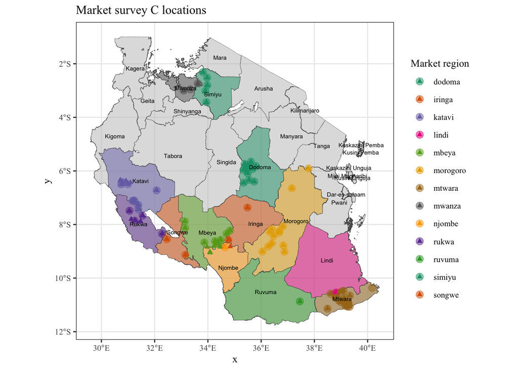

# Market Survey C Data: Overview

*From the EcoPPR Field Guide:*

- Questionnaire by face-to-face interview with individual people who are buying and/or selling animals in the market, about the sources and destinations of the animals, the reasons for buying and/or selling, transport method, trading patterns and disease problems.

**Data Collection Method**

- A minimum of 20 people should be interviewed, or 10% of the people buying and/or selling in the market, whichever is greater, depending on the size of the market.
- The people to be interviewed should be selected randomly or systematically to obtain a representative sample of all types of buyer and sellers and to avoid bias.
  - The research team for each country should discuss how their markets are laid out and make a plan of how to obtain an unbiased sample.
  - If the markets are laid out in a rectangular enclosure, then the field team should walk a transect from one corner of the market, diagonally across the market area to the opposite corner, interviewing every person buying and selling that they meet along the transect. Having completed one transect, if more interviews are required, a second transect can be made starting in a different corner.
  - If the market is circular with all the people buying and selling arranged around the edge with very few in the middle, then the team can start at one point and move around the edge of the circle, interviewing everyone that they meet.
  - Having completed the transects or circle, it may become clear that some key types of buyers or sellers have been missed e.g. sometimes the commercial traders are very busy and moving quickly in the market place so the team has not managed to meet many during the transect. In this case, they can be purposively tracked down for interview in addition to the 20 people/10% people interviewed in the main market area

## 1) What fields are contained in the cleaned survey data?

- Market survey identifiers: date, location data
- Market info: market type, respondent role (trader or otherwise), number of markets visited

```
##  [1] "fid"                                 "date"
##  [3] "date.end"                            "date.of.interview"
##  [5] "date.final"                          "country"
##  [7] "region.final"                        "district.final"
##  [9] "ward.final"                          "village.final"
## [11] "market.final"                        "market.type"
## [13] "respondent.role"                     "other.market.visited"
## [15] "number.markets.visited"              "trader"
## [17] "trade.pattern"                       "gps.coordinates.of.the.market.final"
## [19] "unique.row.identifier.uuid."
```

## 2) How many surveys are there, in total?

- How many surveys were completed?
- How many surveys were completed at each market?
- *Each row of data corresponds to a unique market survey (C)*
- *Each survey is associated with a unique market name, which can be used to group data*

```
## [1] "There are  3310  rows of data corresponding to unique surveys."
```

```
## [1] "There are  83  unique markets"
```

- Market survey A has 85 markets, 2 markets from survey A do not appear in survey C:

| uniqueMrktId |
| --- |
| mtwara-mtwara.urban-naliendele-mwenge-mwenge |
| katavi-mlele-usevya-kitupa-majimoto.b |

## 3) Surveys per Market

*How many surveys were completed at each Market?*

### Surveys per Market (All)

- According to field design there should be a minimum of 20 surveys conducted at each market.
- This is true for most markets except those in Mtwara, Ruvuma and Lindi
  - Ruvuma and Lindi markets are on boundary/visited due to vicinity to Mtwara.

| region.final | uniqueMrkt | n |
| --- | --- | --- |
| dodoma | dodoma-bahi-babayu-kongogo-kongogo | 42 |
| dodoma | dodoma-bahi-bahi-bahi.sokoni-bahi | 44 |
| dodoma | dodoma-bahi-ibihwa-mnkola-mnkola | 30 |
| dodoma | dodoma-bahi-ibugule-nkhome-nkhome | 48 |
| dodoma | dodoma-bahi-kigwe-kigwe-kigwe | 56 |
| dodoma | dodoma-bahi-lamaiti-lamaiti-lamaiti | 45 |
| dodoma | dodoma-bahi-makanda-makanda-makanda | 44 |
| dodoma | dodoma-bahi-msisi-msisi-msisi | 30 |
| dodoma | dodoma-bahi-mundemu-mundemu-mundemu | 22 |
| dodoma | dodoma-bahi-nondwa-nondwa-nondwa | 27 |

[output cut: 73 more lines]

### Surveys per Market (<20)

- Markets with fewer than 20 surveys:

| region.final | uniqueMrkt | n |
| --- | --- | --- |
| lindi | lindi-nachingwea-ndomoni-ndomoni-ndomoni | 8 |
| mtwara | mtwara-masasi-chikolopola-chikolopola-chikolopola | 4 |
| mtwara | mtwara-masasi-lukuledi-lukuledi-lukuledi | 19 |
| mtwara | mtwara-masasi-mnavira-mnavira-mnavira | 4 |
| mtwara | mtwara-masasi-mwena-chibwini-mwena | 12 |
| mtwara | mtwara-masasi-nanganga-mwongozo-nangoo | 8 |
| mtwara | mtwara-masasi.township.authority-migongo-nangaya-nangaya | 10 |
| mtwara | mtwara-masasi.township.authority-mkuti-madeco-madeco | 9 |
| mtwara | mtwara-masasi.township.authority-nyasa-upanga-upanga | 1 |
| mtwara | mtwara-newala-kitangari-kitangari-kitangari | 4 |

[output cut: 5 more lines]

### Surveys per Market (Histogram)

- Histogram of number of surveys at each market location

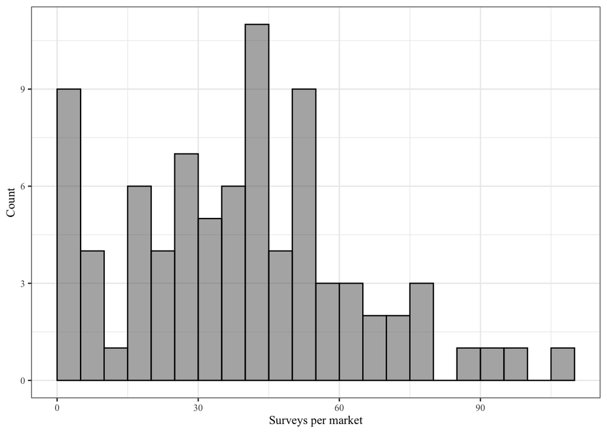

### Surveys per Market (No Mtwara)

- Histogram of number of surveys at each market location **excluding** informal Mtwara markets

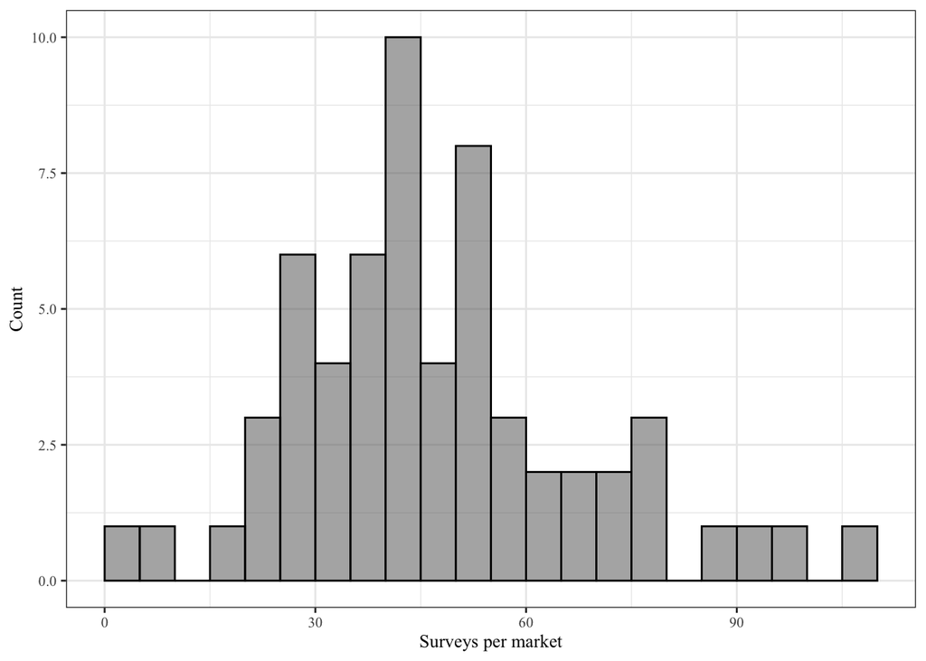

### Market Surveys - by Region (boxplot)

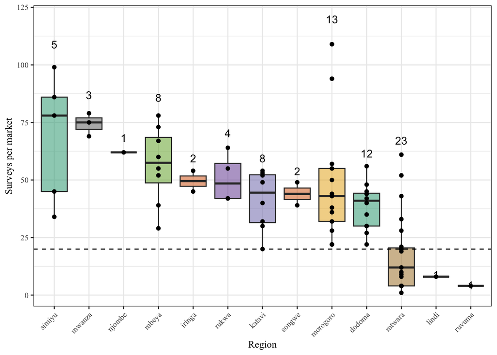

## Market Type:

- Each respondent is asked the type of market. This question is also asked in market survey A (all reported as primary market)
- Theoretically all respondents at a given market should respond with the same market type designation
- This is not the case so this data is not very reliable.

**Market Type Definitions**

- Primary market: located close to the place of production or rearing of small ruminants, usually located within villages or small towns.
- Secondary market: usually found in suburbs, animals are transported some distance from their place of production/rearing to the market.
- Tertiary or final consumption market: generally located in towns or populated areas to supply urban populations, animals are transported quite a long-distance from their place of production/rearing.

### Market Type (Overall)

| market.type.lkp | n |
| --- | --- |
| Primary | 3293 |
| Secondary | 10 |
| Tertiary | 7 |

### Market Type (Regional)

| region.final | Primary | Secondary | Tertiary |
| --- | --- | --- | --- |
| dodoma | 458 | 3 | 2 |
| iringa | 99 | 0 | 0 |
| katavi | 329 | 1 | 0 |
| lindi | 8 | 0 | 0 |
| mbeya | 449 | 2 | 2 |
| morogoro | 630 | 0 | 0 |
| mtwara | 403 | 1 | 1 |
| mwanza | 222 | 0 | 1 |
| njombe | 61 | 1 | 0 |
| rukwa | 202 | 0 | 1 |

[output cut: 3 more lines]

### Market Type (Regional) - Hist

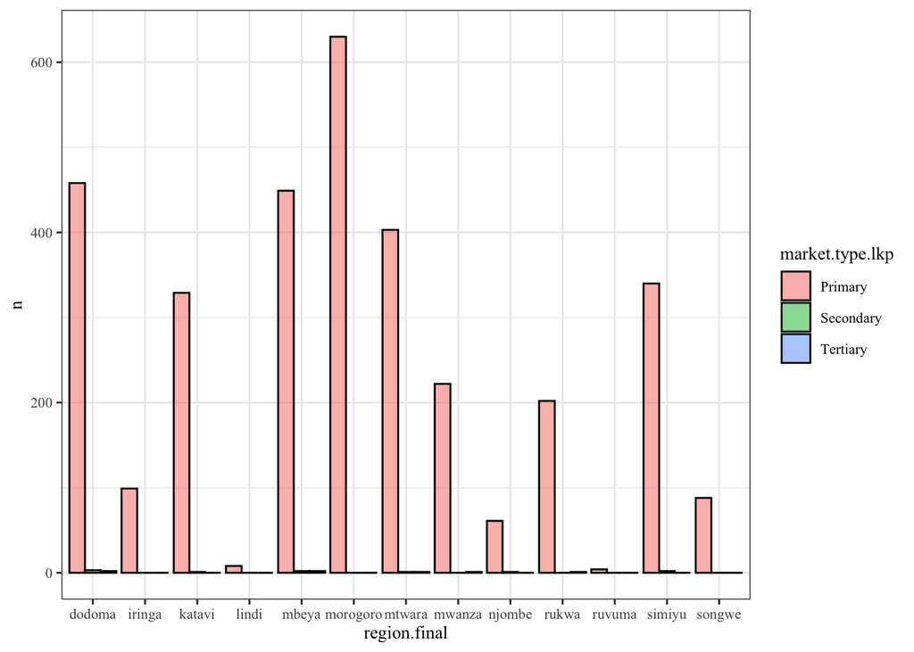

## Trade & Market Attendance

- Number/proportion of tradespeople attending a market can be useful in determining the “type” of that market.

*The total proportion of tradespeople in the data:*

```
## [1] "Overall 39.7 % of respondents identified as Traders ( 1314 out of 3310 respondents)"
```

| trader | n | prop |
| --- | --- | --- |
| 0 | 1996 | 0.6 |
| 1 | 1314 | 0.4 |

### Traders per Market (Hist)

- The number of traders per market:

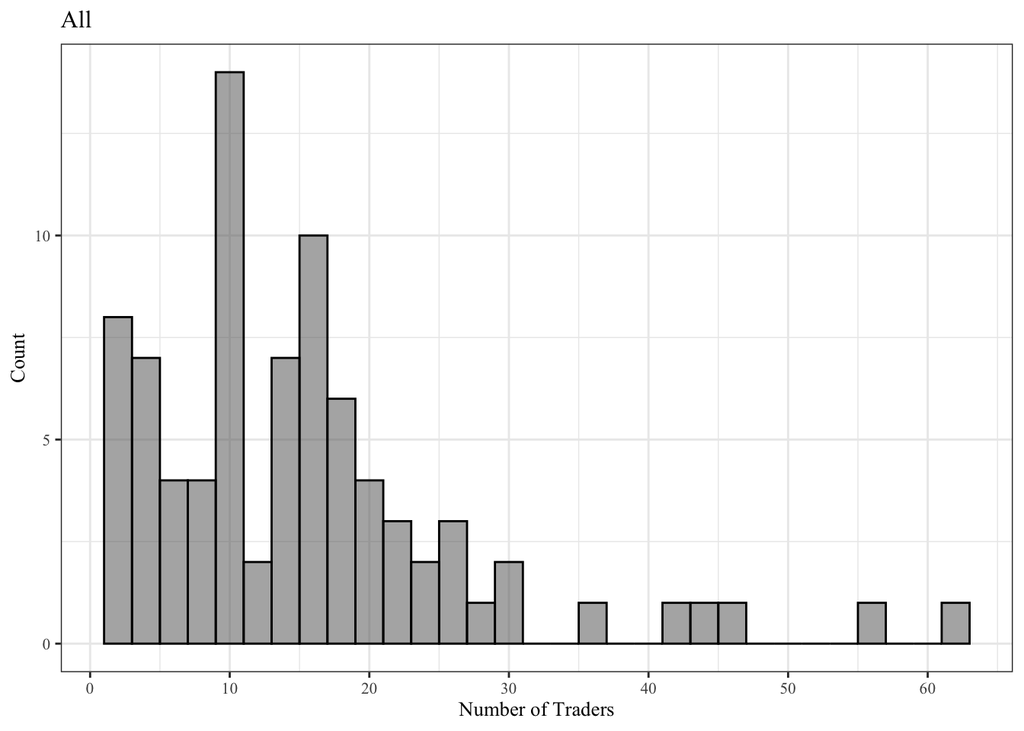

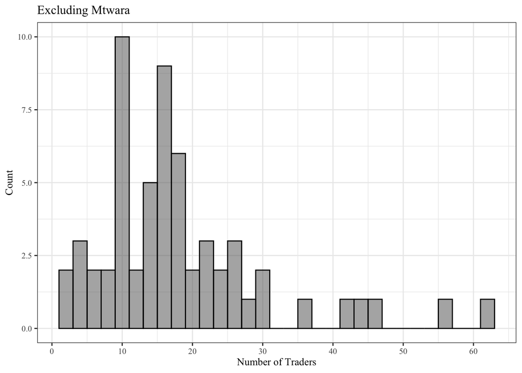

### Traders per market (table)

- The number and proportion of traders at each market:

| region.final | market.final | trader | n | prop |
| --- | --- | --- | --- | --- |
| dodoma | bahi | 0 | 33 | 0.75 |
| dodoma | bahi | 1 | 11 | 0.25 |
| dodoma | kigwe | 0 | 30 | 0.54 |
| dodoma | kigwe | 1 | 26 | 0.46 |
| dodoma | kongogo | 0 | 21 | 0.50 |
| dodoma | kongogo | 1 | 21 | 0.50 |
| dodoma | lamaiti | 0 | 39 | 0.87 |
| dodoma | lamaiti | 1 | 6 | 0.13 |
| dodoma | makanda | 0 | 28 | 0.64 |
| dodoma | makanda | 1 | 16 | 0.36 |

[output cut: 153 more lines]

### Proportion traders per market (hist)

- The proportion of traders at each market:

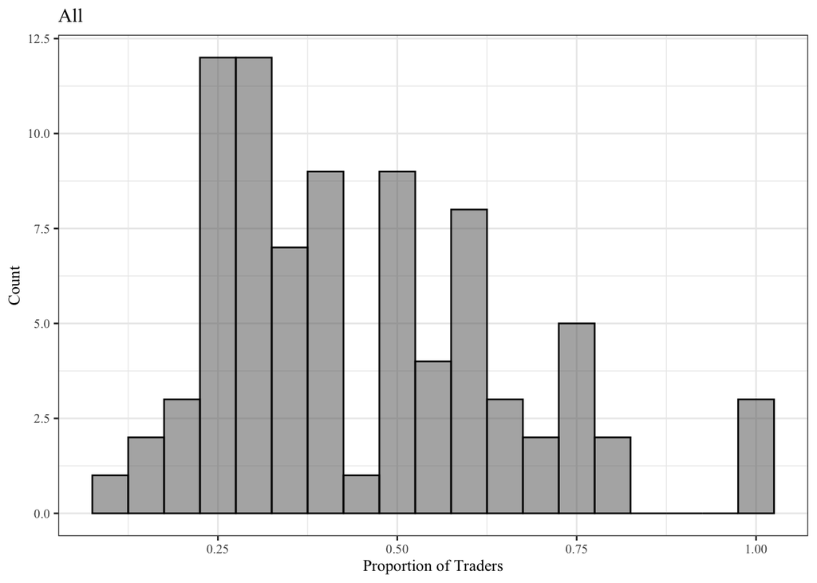

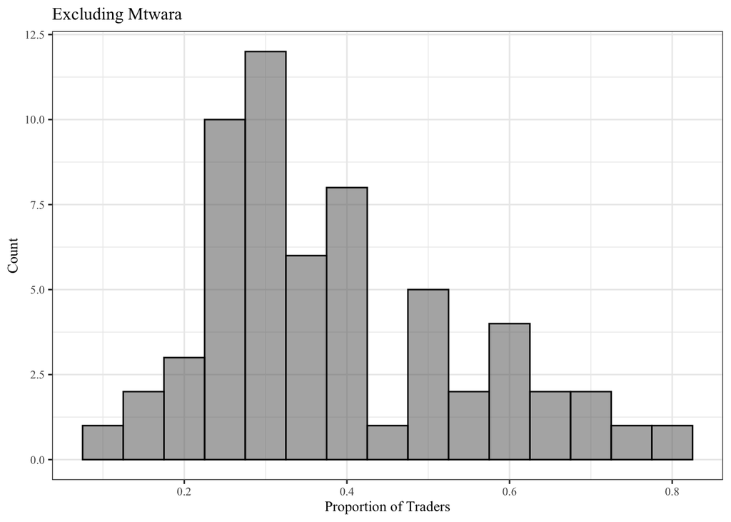

### Traders per market - by Region

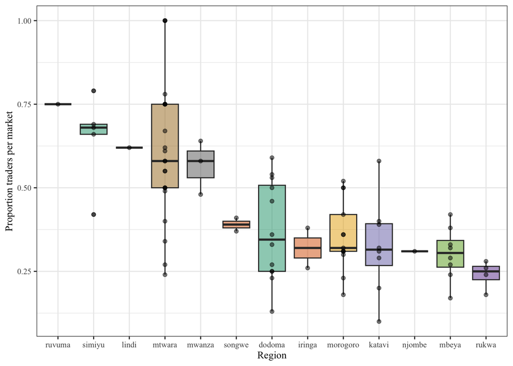

## Other Market Attendance

### Other Market Attendance (All)

Attendance at other markets by respondents to buyer-seller questionnaire

| number.markets.visited | n |
| --- | --- |
| 0 | 1409 |
| 1 | 789 |
| 2 | 556 |
| 3 | 361 |
| 4 | 124 |
| 5 | 55 |
| 6 | 11 |
| 7 | 2 |
| 8 | 2 |
| 10 | 1 |

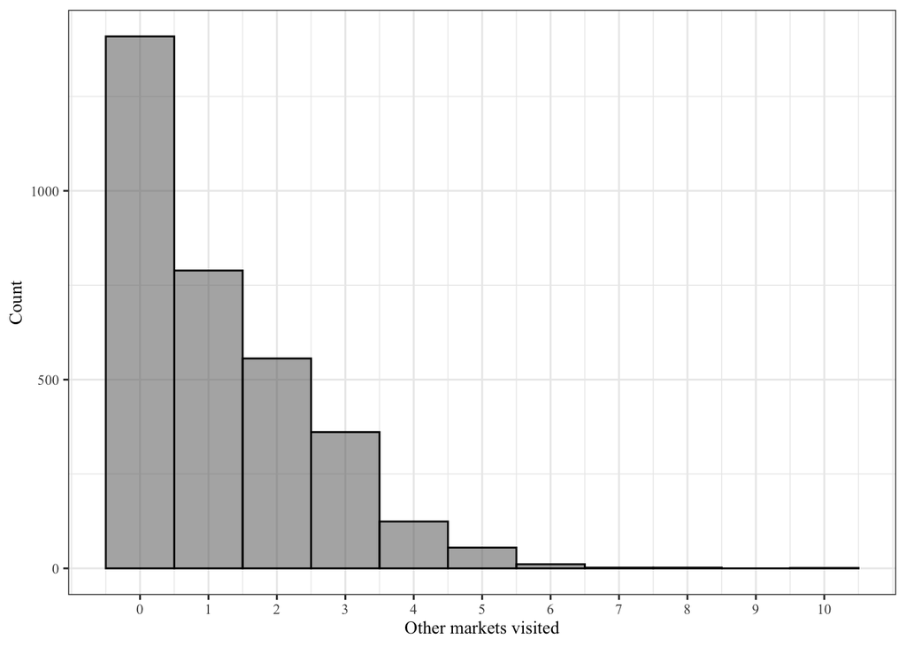

### Other Market Attendance (Trader)

- Market attendance grouped by trader

| number.markets.visited | trader | n |
| --- | --- | --- |
| 0 | 0 | 1105 |
| 0 | 1 | 304 |
| 1 | 0 | 426 |
| 1 | 1 | 363 |
| 2 | 0 | 267 |
| 2 | 1 | 289 |
| 3 | 0 | 144 |
| 3 | 1 | 217 |
| 4 | 0 | 40 |
| 4 | 1 | 84 |

[output cut: 8 more lines]

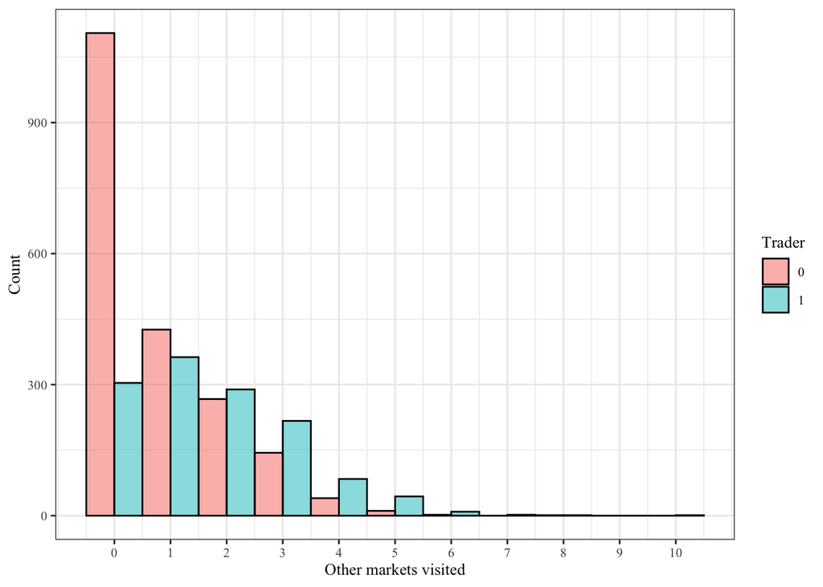

### Market attendance by region

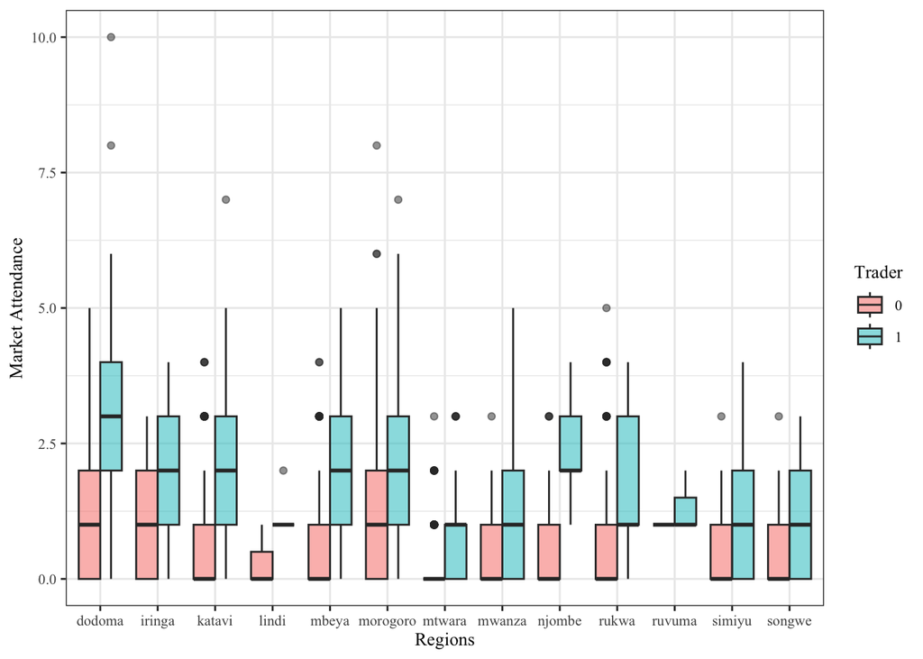

### Market attendance by region (Traders) - boxplot

- Boxplot of number of markets visited, by trader, in each region

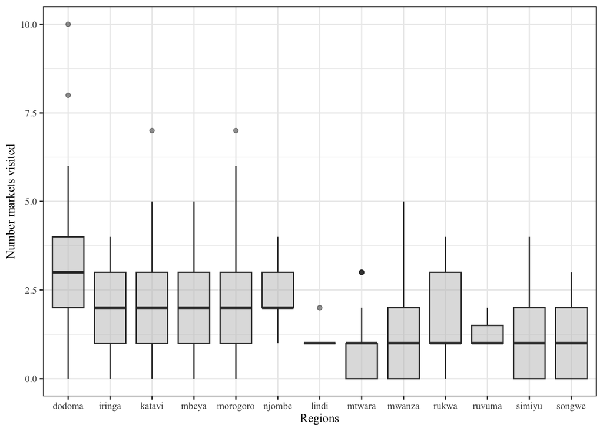

### Market attendance by region (Traders) - histogram

- Number markets visited grouped, by trader, in each region

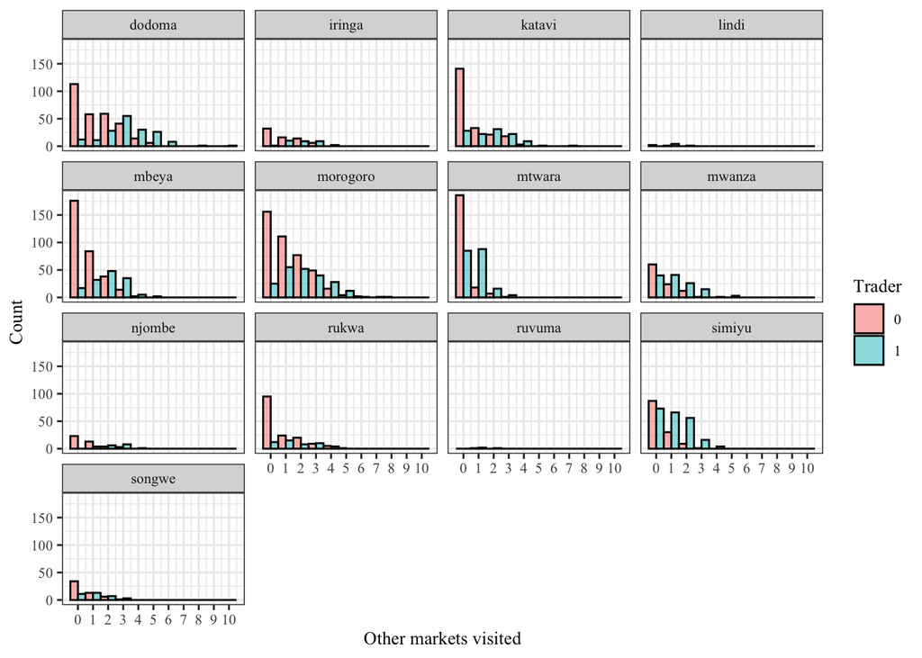